# Getting data from the web: API access

MACS 30500 University of Chicago

February 20, 2017

# How to get data online

- Click-and-download
- Install-and-play
- API-query
- Scraping

# Click-and-Download

- Use `read.csv` or `readr::read_csv` to read the data straight into R
- Store, then read
  - Download using `downloader` for R or `curl` from the shell
  - Then read into R using `read_csv`
  - Even if the file disappears from the internet, you have a local copy cached

# APIs

- **A**pplication **P**rogramming **I**nterfaces
- Many websites use APIs to allow programatic access
  - Clients sends request to server
  - Server responds by sending data (or an error message)
- Clients
  - Phone app
  - R/Python

# Install and play packages

- Pre-wrapped packages for APIs
- Reproducible
- Updating
- Ease
- Scaling

# Sightings of birds: `rebird`

- [`ebird`](http://ebird.org) - online database of bird sightings
- [`rebird`](https://github.com/ropensci/rebird) - R package to interface with e-Bird

# Search birds by geography

[figure not shown]

# Search birds by geography

```r
library(rebird)
```

```r
ebirdhotspot(locID = "L1573785") %>%
  tbl_df()
```

```
## # A tibble: 4 × 11
##         lng                   locName howMany            sciName obsValid
##       <dbl>                     <chr>   <int>              <chr>    <lgl>
## 1 -87.63272 Lincoln Park Zoo, Chicago     100 Anas platyrhynchos     TRUE
## 2 -87.63272 Lincoln Park Zoo, Chicago       4 Bucephala clangula     TRUE
## 3 -87.63272 Lincoln Park Zoo, Chicago       1 Accipiter cooperii     TRUE
## 4 -87.63272 Lincoln Park Zoo, Chicago       9  Passer domesticus     TRUE
## # ... with 6 more variables: locationPrivate <lgl>, obsDt <chr>,
## #   obsReviewed <lgl>, comName <chr>, lat <dbl>, locID <chr>
```

# Search birds by geographic area

```r
chibirds <- ebirdgeo(lat = 41.8781, lng = -87.6298)
chibirds %>%
  tbl_df()
```

```
## # A tibble: 112 × 11
##          lng                               locName               sciName
##        <dbl>                                 <chr>                 <chr>
## 1  -87.63442 Montrose Point, Lincoln Park, Chicago Corvus brachyrhynchos
## 2  -87.63442 Montrose Point, Lincoln Park, Chicago         Columba livia
## 3  -87.63442 Montrose Point, Lincoln Park, Chicago    Larus delawarensis
## 4  -87.63442 Montrose Point, Lincoln Park, Chicago       Mergus serrator
## 5  -87.63442 Montrose Point, Lincoln Park, Chicago Cardinalis cardinalis
## 6  -87.63442 Montrose Point, Lincoln Park, Chicago    Anas platyrhynchos
## 7  -87.63442 Montrose Point, Lincoln Park, Chicago     Passer domesticus
## 8  -87.63442 Montrose Point, Lincoln Park, Chicago  Haemorhous mexicanus
## 9  -87.63442 Montrose Point, Lincoln Park, Chicago      Larus argentatus
## 10 -87.63442 Montrose Point, Lincoln Park, Chicago      Sturnus vulgaris
## # ... with 102 more rows, and 8 more variables: obsValid <lgl>,
## #   locationPrivate <lgl>, obsDt <chr>, obsReviewed <lgl>, comName <chr>,
## #   lat <dbl>, locID <chr>, howMany <int>
```

# Search birds by geographic region

```r
frenchbirds <- ebirdregion("FR")
frenchbirds %>%
  tbl_df()
```

```
## # A tibble: 198 × 11
##         lng                   locName                    sciName obsValid
##       <dbl>                     <chr>                      <chr>    <lgl>
## 1  2.795296 Trilbardou--Les Olivettes Chroicocephalus ridibundus     TRUE
## 2  2.795296 Trilbardou--Les Olivettes          Larus michahellis     TRUE
## 3  2.795296 Trilbardou--Les Olivettes    Troglodytes troglodytes     TRUE
## 4  2.795296 Trilbardou--Les Olivettes            Aythya fuligula     TRUE
## 5  2.795296 Trilbardou--Les Olivettes              Columba oenas     TRUE
## 6  2.795296 Trilbardou--Les Olivettes          Turdus philomelos     TRUE
## 7  2.795296 Trilbardou--Les Olivettes         Psittacula krameri     TRUE
## 8  3.854707       Eco&Sols--Oliveraie              Columba livia     TRUE
## 9  2.795296 Trilbardou--Les Olivettes               Netta rufina     TRUE
## 10 2.795296 Trilbardou--Les Olivettes              Anas clypeata     TRUE
## # ... with 188 more rows, and 7 more variables: locationPrivate <lgl>,
## #   obsDt <chr>, obsReviewed <lgl>, comName <chr>, lat <dbl>, locID <chr>,
## #   howMany <int>
```

# Search birds by species

```r
warbler <- ebirdgeo(species = 'Setophaga coronata', lat = 41.8781, lng = -87.6298)
warbler %>%
  tbl_df()
```

```
## # A tibble: 4 × 11
##         lng                                    locName howMany
##       <dbl>                                      <chr>   <int>
## 1 -87.73214          US-IL-Evanston-2650 Princeton Ave       1
## 2 -87.77300 Harms Woods/Glenview Woods Forest Preserve       1
## 3 -87.74066             Memorial Park Cemetery, Skokie       1
## 4 -87.78226                           352 Graemere St.       1
## # ... with 8 more variables: sciName <chr>, obsValid <lgl>,
## #   locationPrivate <lgl>, obsDt <chr>, obsReviewed <lgl>, comName <chr>,
## #   lat <dbl>, locID <chr>
```

# Use known location

```r
ebirdgeo(species = 'Setophaga coronata') %>%
  tbl_df()
```

```
## # A tibble: 0 × 0
```

# Searching geographic info: `geonames`

```r
# install.packages(geonames)
library(geonames)
```

# API authentication

- Registering for access
- API key/token
- Rate-limiting

# Accessing the geonames API

1. Go to the geonames site and register an account
2. Click [here to enable the free web service](http://www.geonames.org/enablefreewebservice)
3. Tell R your geonames username

# Bad API key storage

```r
library(geonames)
options(geonamesUsername = "my_user_name")

# All my code here
```

# Good API key storage

```r
options(geonamesUsername = "my_user_name")
```

- `.Rprofile`
- Store in folder with `.Rproj`

# Important details for `.Rprofile`

- Make sure your `.Rprofile` ends with a blank line
- Make sure `.Rprofile` is included in your `.gitignore` file
- Restart RStudio after modifying `.Rprofile`
- Check your spelling
- You can do a similar process for an arbitrary package or key. For example:

  ```r
  # in .Rprofile
  options("this_is_my_key" = XXXX)

  # later, in the R script:
  key <- getOption("this_is_my_key")
  ```

# using Geonames

```r
countryInfo <- GNcountryInfo()
countryInfo %>%
    tbl_df()
```

```
## # A tibble: 250 × 17
##    continent          capital            languages geonameId
##        <chr>            <chr>                <chr>     <chr>
## 1         EU Andorra la Vella                   ca   3041565
## 2         AS        Abu Dhabi    ar-AE,fa,en,hi,ur    290557
## 3         AS            Kabul    fa-AF,ps,uz-AF,tk   1149361
## 4         NA     Saint John’s                en-AG   3576396
## 5         NA       The Valley                en-AI   3573511
## 6         EU           Tirana                sq,el    783754
## 7         AS          Yerevan                   hy    174982
## 8         AF           Luanda                pt-AO   3351879
## 9         AN                                         6697173
## 10        SA     Buenos Aires es-AR,en,it,de,fr,gn   3865483
## # ... with 240 more rows, and 13 more variables: south <chr>,
## #   isoAlpha3 <chr>, north <chr>, fipsCode <chr>, population <chr>,
## #   east <chr>, isoNumeric <chr>, areaInSqKm <chr>, countryCode <chr>,
## #   west <chr>, countryName <chr>, continentName <chr>, currencyCode <chr>
```

# `rplos`

```r
library(rplos)
searchplos(q = "alcohol", fl = "id,title", limit = 10)
```

```
## $meta
##   numFound start maxScore
## 1    23665     0       NA
##
## $data
##                              id
## 1  10.1371/journal.pmed.0040151
## 2  10.1371/journal.pone.0027752
## 3  10.1371/journal.pmed.0050108
## 4  10.1371/journal.pone.0071284
## 5  10.1371/journal.pone.0137790
## 6  10.1371/journal.pone.0153027
## 7  10.1371/journal.pone.0022994
## 8  10.1371/journal.pmed.0050104
## 9  10.1371/journal.pone.0099906
## 10 10.1371/journal.pone.0067386
##                                                                                                                                                                     title
## 1                                                                                                        Comparative Analysis of Alcohol Control Policies in 30 Countries
## 2                        Feasibility of an Alcohol Intervention Programme for TB Patients with Alcohol Use Disorder (AUD) - A Qualitative Study from Chennai, South India
## 3                                                                                                       Retail Sales of Alcohol and the Risk of Being a Victim of Assault
## 4  Ghrelin Receptor (GHS-R1A) Antagonism Suppresses Both Alcohol Consumption and the Alcohol Deprivation Effect in Rats following Long-Term Voluntary Alcohol Consumption
## 5                                                  Alcohol Use and Gamma-Glutamyltransferase Using a Mendelian Randomization Design in the Guangzhou Biobank Cohort Study
## 6                                                      Health Warnings on Alcoholic Beverages: Perceptions of the Health Risks and Intentions towards Alcohol Consumption
## 7                                                                                                               Evaluation of Un-Medicated, Self-Paced Alcohol Withdrawal
## 8                                                                                                                               Alcohol Sales and Risk of Serious Assault
## 9                                            Alcohol Tax Policy and Related Mortality. An Age-Period-Cohort Analysis of a Rapidly Developed Chinese Population, 1981–2010
## 10                          An Experimental Trial Exploring the Impact of Continuous Transdermal Alcohol Monitoring upon Alcohol Consumption in a Cohort of Male Students
```

# Relative frequency plot

```r
out <- plosword(list("alcohol", "heroin", "marijuana"),
    vis = "TRUE")
out$table
```

```
##   No_Articles      Term
## 1       23665   alcohol
## 2         766    heroin
## 3         541 marijuana
```

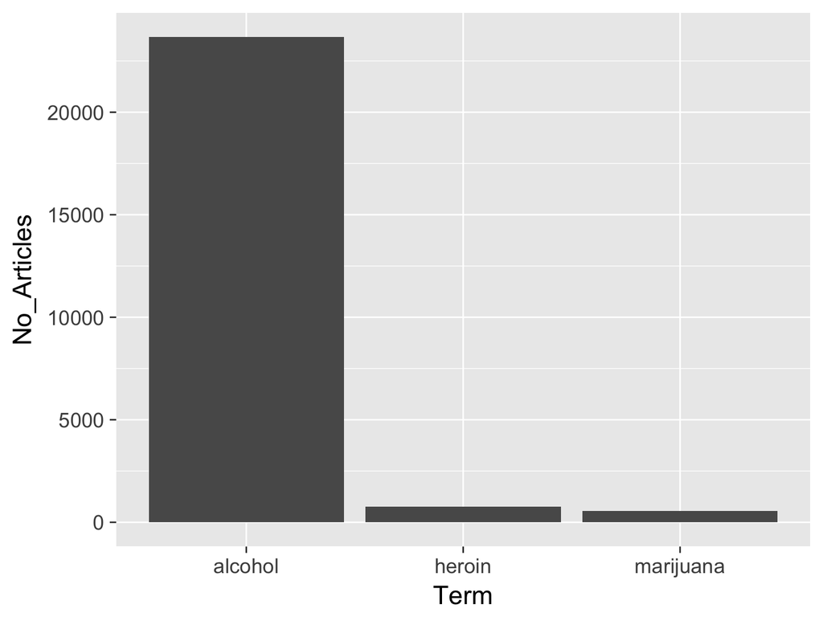

```r
out$plot
```

# Plots over time

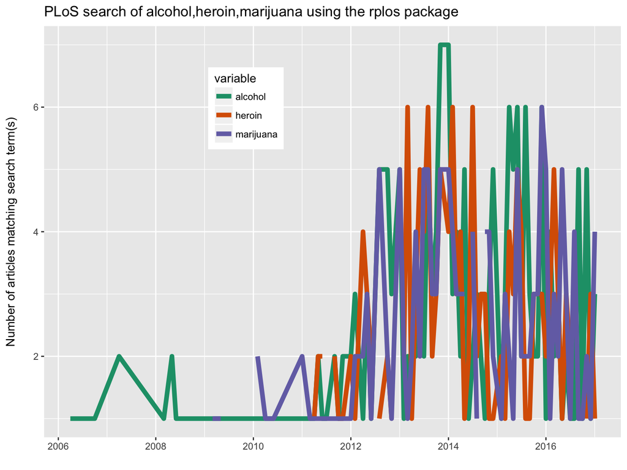

```r
plot_throughtime(terms = c("alcohol", "heroin", "marijuana"), limit = 200)
```

# Scraping Twitter

1. *REST* API
2. *Streaming* API

# Packages for Twitter

- [`twitteR`](https://cran.rstudio.com/web/packages/twitteR/index.html)
- [`streamR`](https://cran.rstudio.com/web/packages/streamR/index.html)
- [`tweepy`](http://www.tweepy.org/)

# OAuth authentication

1. Create a Twitter application for yourself
2. Store your API key and token using the `.Rprofile` method.

   ```r
   options(twitter_api_key = "Your API key")
   options(twitter_api_token = "Your API secret")
   ```

3. Run from the console:

   ```r
   library(twitteR)
   setup_twitter_oauth(consumer_key = getOption("twitter_api_key"),
                       consumer_secret = getOption("twitter_api_token"))
   ```

4. At this point you should get a message back in RStudio “Authentication complete.”

# Searching tweets

```r
tweets <- searchTwitter('#rstats', n = 5)
tweets
```

```
## [[1]]
## [1] "renato_umeton: RT @Rbloggers: Chop It: Look up the Generating Data Frame Columns of a Formula Term https://t.co/Y25rPsRcxo #rstats #DataScience"
##
## [[2]]
## [1] "bhart214: RT @sharon000: Videos from the RStudio conference are now online (and available for free viewing) #rstats \nhttps://t.co/APirFyYalR https://…"
##
## [[3]]
## [1] "DeborahTannon: #RStats —Chop It: Look up the Generating Data Frame Columns of a Formula Term : https://t.co/53AagY1Yc5"
##
## [[4]]
## [1] "mikejonesmelb: RT @genetics_blog: #Rstats pkg CatterPlots, just in case you needed to make a scatterplot with cat-shaped points. https://t.co/zs0No5JZee h…"
##
## [[5]]
## [1] "TylerJBurch: RT @genetics_blog: #Rstats pkg CatterPlots, just in case you needed to make a scatterplot with cat-shaped points. https://t.co/zs0No5JZee h…"
```

# Searching users

```r
clinton <- getUser("hillaryclinton")
clinton$getDescription()
```

```
## [1] "Wife, mom, grandma, women+kids advocate, FLOTUS, Senator, SecState, hair icon, pantsuit aficionado, 2016 presidential candidate."
```

```r
clinton$getFriends(n = 5)
```

```
## $`3004231`
## [1] "SnoopDogg"
##
## $`3153892631`
## [1] "RobbyMook"
##
## $`18730233`
## [1] "daniellekantor"
##
## $`4732338444`
## [1] "RyanForRecovery"
```

# Tidying tweets

```r
str(tweets)
```

```
## List of 5
##  $ :Reference class 'status' [package "twitteR"] with 17 fields
##   ..$ text         : chr "RT @Rbloggers: Chop It: Look up the Generating Data Frame Columns of a Formula Term https://t.co/Y25rPsRcxo #rstats #DataScienc"| __truncated__
##   ..$ favorited    : logi FALSE
##   ..$ favoriteCount: num 0
##   ..$ replyToSN    : chr(0)
##   ..$ created      : POSIXct[1:1], format: "2017-02-16 22:28:26"
##   ..$ truncated    : logi FALSE
##   ..$ replyToSID   : chr(0)
##   ..$ id           : chr "832355988007157761"
##   ..$ replyToUID   : chr(0)
##   ..$ statusSource : chr "<a href=\"http://umeton.com\" rel=\"nofollow\">rtapp315156161</a>"
##   ..$ screenName   : chr "renato_umeton"
##   ..$ retweetCount : num 1
##   ..$ isRetweet    : logi TRUE
##   ..$ retweeted    : logi FALSE
##   ..$ longitude    : chr(0)
##   ..$ latitude     : chr(0)
##   ..$ urls         :'data.frame':    1 obs. of  5 variables:
##   .. ..$ url         : chr "https://t.co/Y25rPsRcxo"
##   .. ..$ expanded_url: chr "https://wp.me/pMm6L-Ckx"
##   .. ..$ display_url : chr "wp.me/pMm6L-Ckx"
##   .. ..$ start_index : num 84
##   .. ..$ stop_index  : num 107
##   ..and 53 methods, of which 39 are  possibly relevant:
##   ..  getCreated, getFavoriteCount, getFavorited, getId, getIsRetweet,
##   ..  getLatitude, getLongitude, getReplyToSID, getReplyToSN,
##   ..  getReplyToUID, getRetweetCount, getRetweeted, getRetweeters,
##   ..  getRetweets, getScreenName, getStatusSource, getText, getTruncated,
##   ..  getUrls, initialize, setCreated, setFavoriteCount, setFavorited,
##   ..  setId, setIsRetweet, setLatitude, setLongitude, setReplyToSID,
##   ..  setReplyToSN, setReplyToUID, setRetweetCount, setRetweeted,
##   ..  setScreenName, setStatusSource, setText, setTruncated, setUrls,
##   ..  toDataFrame, toDataFrame#twitterObj
##  $ :Reference class 'status' [package "twitteR"] with 17 fields
##   ..$ text         : chr "RT @sharon000: Videos from the RStudio conference are now online (and available for free viewing) #rstats \nhttps://t.co/APirFy"| __truncated__
##   ..$ favorited    : logi FALSE
##   ..$ favoriteCount: num 0
##   ..$ replyToSN    : chr(0)
##   ..$ created      : POSIXct[1:1], format: "2017-02-16 22:28:19"
```

[output cut: 111 more lines]

```
##   .. ..$ url         : chr "https://t.co/zs0No5JZee"
##   .. ..$ expanded_url: chr "https://github.com/Gibbsdavidl/CatterPlots"
##   .. ..$ display_url : chr "github.com/Gibbsdavidl/Ca…"
##   .. ..$ start_index : num 114
##   .. ..$ stop_index  : num 137
##   ..and 53 methods, of which 39 are  possibly relevant:
##   ..  getCreated, getFavoriteCount, getFavorited, getId, getIsRetweet,
##   ..  getLatitude, getLongitude, getReplyToSID, getReplyToSN,
##   ..  getReplyToUID, getRetweetCount, getRetweeted, getRetweeters,
##   ..  getRetweets, getScreenName, getStatusSource, getText, getTruncated,
##   ..  getUrls, initialize, setCreated, setFavoriteCount, setFavorited,
##   ..  setId, setIsRetweet, setLatitude, setLongitude, setReplyToSID,
##   ..  setReplyToSN, setReplyToUID, setRetweetCount, setRetweeted,
##   ..  setScreenName, setStatusSource, setText, setTruncated, setUrls,
##   ..  toDataFrame, toDataFrame#twitterObj
```

# Tidying tweets

```r
df <- twListToDF(tweets) %>%
  tbl_df()
df
```

```
## # A tibble: 5 × 16
##                                                                          text
## *                                                                       <chr>
## 1 RT @Rbloggers: Chop It: Look up the Generating Data Frame Columns of a Form
## 2 RT @sharon000: Videos from the RStudio conference are now online (and avail
## 3 #RStats —Chop It: Look up the Generating Data Frame Columns of a Formula Te
## 4 RT @genetics_blog: #Rstats pkg CatterPlots, just in case you needed to make
## 5 RT @genetics_blog: #Rstats pkg CatterPlots, just in case you needed to make
## # ... with 15 more variables: favorited <lgl>, favoriteCount <dbl>,
## #   replyToSN <lgl>, created <dttm>, truncated <lgl>, replyToSID <lgl>,
## #   id <chr>, replyToUID <lgl>, statusSource <chr>, screenName <chr>,
## #   retweetCount <dbl>, isRetweet <lgl>, retweeted <lgl>, longitude <lgl>,
## #   latitude <lgl>
```

# Practice using `twitteR`

1. Create a new R project on your computer
2. Setup your API key with a Twitter app.
3. Authenticate using the `twitteR` package in R
4. Find the 50 most recent tweets by Donald Trump and store them in a data frame.
   - `userTimeline()` can be used to retrieve tweets from individual users
   - `searchTwitter()` finds tweets from any public account that references the username